# Assignment 2

Sagnik Chakravarty

## Setup

```r
library(glmnet)
library(caret)
```

## Data

For this exercise we use the Communities and Crime data from the UCI ML repository, which includes information about communities in the US. “The data combines socio-economic data from the 1990 US Census, law enforcement data from the 1990 US LEMAS survey, and crime data from the 1995 FBI UCR”

Source: https://archive.ics.uci.edu/ml/datasets/Communities+and+Crime

First, some data prep.

```r
crime <- read.csv("communities.data", header = FALSE, na.strings = "?")
varnames <- read.delim("communities.txt", header = FALSE)
```

Clean name vector and use as variable names.

```r
varnames <- as.character(varnames$V1)
varnames <- gsub("@attribute ", "", varnames)
varnames <- gsub(" numeric", "", varnames)
varnames <- gsub(" string", "", varnames)
names(crime) <- varnames
```

To make things easier, drop columns with missing values.

```r
crime <- crime[, colSums(is.na(crime)) == 0]
```

Check whats left.

```r
str(crime)
```

```
## 'data.frame':    1994 obs. of  103 variables:
##  $ state                : int  8 53 24 34 42 6 44 6 21 29 ...
##  $ communityname        : chr  "Lakewoodcity" "Tukwilacity" "Aberdeentown" "Willingborotownship" ...
##  $ fold                 : int  1 1 1 1 1 1 1 1 1 1 ...
##  $ population           : num  0.19 0 0 0.04 0.01 0.02 0.01 0.01 0.03 0.01 ...
##  $ householdsize        : num  0.33 0.16 0.42 0.77 0.55 0.28 0.39 0.74 0.34 0.4 ...
##  $ racepctblack         : num  0.02 0.12 0.49 1 0.02 0.06 0 0.03 0.2 0.06 ...
##  $ racePctWhite         : num  0.9 0.74 0.56 0.08 0.95 0.54 0.98 0.46 0.84 0.87 ...
##  $ racePctAsian         : num  0.12 0.45 0.17 0.12 0.09 1 0.06 0.2 0.02 0.3 ...
##  $ racePctHisp          : num  0.17 0.07 0.04 0.1 0.05 0.25 0.02 1 0 0.03 ...
##  $ agePct12t21          : num  0.34 0.26 0.39 0.51 0.38 0.31 0.3 0.52 0.38 0.9 ...
##  $ agePct12t29          : num  0.47 0.59 0.47 0.5 0.38 0.48 0.37 0.55 0.45 0.82 ...
##  $ agePct16t24          : num  0.29 0.35 0.28 0.34 0.23 0.27 0.23 0.36 0.28 0.8 ...
##  $ agePct65up           : num  0.32 0.27 0.32 0.21 0.36 0.37 0.6 0.35 0.48 0.39 ...
##  $ numbUrban            : num  0.2 0.02 0 0.06 0.02 0.04 0.02 0 0.04 0.02 ...
```

[output cut: 86 more lines]

## Train and test set

Next, we want to split the data into a training (75%) and a test (25%) part. This can be done by random sampling with `sample`. Note that there is a `fold` variable in the data set, but here we want to follow our own train/test procedure.

```r
set.seed(3940)

train_indices <- sample(1:nrow(crime),
                        size = round(nrow(crime)*0.75))
crime_train <- crime[train_indices,]
crime_test <- crime[-train_indices,]
```

Now, prepare the training data for running regularized regression models via `glmnet`. Our prediction outcome is `ViolentCrimesPerPop`. As X, use all variables except `state`, `communityname`, and `fold`.

```r
X <- model.matrix(ViolentCrimesPerPop~.-state-communityname-fold,
                  data = crime_train)[,-1]

y <- crime_train$ViolentCrimesPerPop
```

Check whether X looks ok.

```r
dim(X)
```

```
## [1] 1496   99
```

### Lasso

Estimate a sequence of Lasso models using `glmnet`. You can stick with the defaults for choosing a range of lambdas.

```r
lasso_model <- glmnet(X, y, alpha = 1)
```

Here we want to display lambda and the coefficients of the first Lasso model.

```r
lasso_model$lambda[1]
```

```
## [1] 0.1736515
```

```r
lasso_model$beta[1]
```

```
## [1] 0
```

Same for the last Lasso model.

```r
lasso_model$lambda[1]
```

```
## [1] 0.1736515
```

```r
lasso_model$lambda[(ncol(lasso_model$beta)/2)]
```

```
## [1] 0.0018192
```

```r
lasso_model$lambda[ncol(lasso_model$beta)]
```

```
## [1] 1.736515e-05
```

```r
lasso_model$beta[,1]
```

```
##            population         householdsize          racepctblack
##                     0                     0                     0
##          racePctWhite          racePctAsian           racePctHisp
##                     0                     0                     0
##           agePct12t21           agePct12t29           agePct16t24
##                     0                     0                     0
##            agePct65up             numbUrban              pctUrban
##                     0                     0                     0
##             medIncome              pctWWage          pctWFarmSelf
##                     0                     0                     0
##            pctWInvInc            pctWSocSec           pctWPubAsst
##                     0                     0                     0
##            pctWRetire             medFamInc             perCapInc
##                     0                     0                     0
##           whitePerCap           blackPerCap          indianPerCap
##                     0                     0                     0
##           AsianPerCap            HispPerCap           NumUnderPov
##                     0                     0                     0
##        PctPopUnderPov       PctLess9thGrade          PctNotHSGrad
##                     0                     0                     0
##           PctBSorMore         PctUnemployed             PctEmploy
##                     0                     0                     0
##           PctEmplManu       PctEmplProfServ          PctOccupManu
##                     0                     0                     0
##      PctOccupMgmtProf        MalePctDivorce        MalePctNevMarr
##                     0                     0                     0
##          FemalePctDiv           TotalPctDiv            PersPerFam
##                     0                     0                     0
##            PctFam2Par           PctKids2Par      PctYoungKids2Par
##                     0                     0                     0
##           PctTeen2Par   PctWorkMomYoungKids            PctWorkMom
##                     0                     0                     0
##              NumIlleg              PctIlleg              NumImmig
##                     0                     0                     0
##        PctImmigRecent          PctImmigRec5          PctImmigRec8
##                     0                     0                     0
##         PctImmigRec10        PctRecentImmig          PctRecImmig5
##                     0                     0                     0
##          PctRecImmig8         PctRecImmig10      PctSpeakEnglOnly
##                     0                     0                     0
```

[output cut: 11 more lines]

```
##                     0                     0                     0
##        OwnOccLowQuart          OwnOccMedVal         OwnOccHiQuart
##                     0                     0                     0
##              RentLowQ            RentMedian             RentHighQ
##                     0                     0                     0
##               MedRent     MedRentPctHousInc      MedOwnCostPctInc
##                     0                     0                     0
## MedOwnCostPctIncNoMtg         NumInShelters             NumStreet
##                     0                     0                     0
##        PctForeignBorn      PctBornSameState        PctSameHouse85
##                     0                     0                     0
##         PctSameCity85        PctSameState85              LandArea
##                     0                     0                     0
##               PopDens        PctUsePubTrans   LemasPctOfficDrugUn
##                     0                     0                     0
```

```r
lasso_model$beta[,(ncol(lasso_model$beta)/2)]
```

```
##            population         householdsize          racepctblack
##          0.0000000000          0.0000000000          0.0998215277
##          racePctWhite          racePctAsian           racePctHisp
##         -0.0635682652          0.0000000000          0.0000000000
##           agePct12t21           agePct12t29           agePct16t24
##          0.0000000000         -0.0693960810          0.0000000000
##            agePct65up             numbUrban              pctUrban
##          0.0051129932          0.0000000000          0.0343221838
##             medIncome              pctWWage          pctWFarmSelf
##          0.0000000000         -0.0573798948          0.0000000000
##            pctWInvInc            pctWSocSec           pctWPubAsst
##         -0.0681378333          0.0000000000          0.0000000000
##            pctWRetire             medFamInc             perCapInc
##         -0.0459533211          0.0000000000          0.0000000000
##           whitePerCap           blackPerCap          indianPerCap
##          0.0000000000          0.0000000000         -0.0134962672
##           AsianPerCap            HispPerCap           NumUnderPov
##          0.0013160389          0.0380405522          0.0000000000
##        PctPopUnderPov       PctLess9thGrade          PctNotHSGrad
##         -0.0369066546          0.0000000000          0.0000000000
##           PctBSorMore         PctUnemployed             PctEmploy
##          0.0000000000          0.0000000000          0.0000000000
##           PctEmplManu       PctEmplProfServ          PctOccupManu
##         -0.0001087687          0.0000000000          0.0000000000
##      PctOccupMgmtProf        MalePctDivorce        MalePctNevMarr
##          0.0000000000          0.0620718768          0.0000000000
##          FemalePctDiv           TotalPctDiv            PersPerFam
##          0.0000000000          0.0000000000          0.0000000000
##            PctFam2Par           PctKids2Par      PctYoungKids2Par
##          0.0000000000         -0.3059489244          0.0000000000
##           PctTeen2Par   PctWorkMomYoungKids            PctWorkMom
##          0.0000000000          0.0000000000         -0.0666471255
##              NumIlleg              PctIlleg              NumImmig
##          0.0000000000          0.2159800071         -0.0867873861
##        PctImmigRecent          PctImmigRec5          PctImmigRec8
##          0.0000000000          0.0000000000          0.0000000000
##         PctImmigRec10        PctRecentImmig          PctRecImmig5
##          0.0000000000          0.0000000000          0.0000000000
##          PctRecImmig8         PctRecImmig10      PctSpeakEnglOnly
##          0.0000000000          0.0000000000          0.0000000000
```

[output cut: 11 more lines]

```
##          0.0000000000          0.0000000000          0.0000000000
##        OwnOccLowQuart          OwnOccMedVal         OwnOccHiQuart
##          0.0000000000          0.0000000000          0.0000000000
##              RentLowQ            RentMedian             RentHighQ
##         -0.0057585793          0.0000000000          0.0000000000
##               MedRent     MedRentPctHousInc      MedOwnCostPctInc
##          0.0353698799          0.0229756789          0.0000000000
## MedOwnCostPctIncNoMtg         NumInShelters             NumStreet
##         -0.0623183987          0.0000000000          0.1770893955
##        PctForeignBorn      PctBornSameState        PctSameHouse85
##          0.0000000000          0.0000000000          0.0000000000
##         PctSameCity85        PctSameState85              LandArea
##          0.0162174329          0.0000000000          0.0000000000
##               PopDens        PctUsePubTrans   LemasPctOfficDrugUn
##          0.0000000000         -0.0036536367          0.0267745625
```

```r
lasso_model$beta[,ncol(lasso_model$beta)]
```

```
##            population         householdsize          racepctblack
##           0.008153358          -0.064225415           0.142508632
##          racePctWhite          racePctAsian           racePctHisp
##          -0.080713821           0.006034638           0.039126885
##           agePct12t21           agePct12t29           agePct16t24
##           0.096507553          -0.212863514          -0.150000635
##            agePct65up             numbUrban              pctUrban
##           0.095320889          -0.112693217           0.047279919
##             medIncome              pctWWage          pctWFarmSelf
##          -0.227478274          -0.290691531           0.039473466
##            pctWInvInc            pctWSocSec           pctWPubAsst
##          -0.118696052          -0.015763592          -0.048212373
##            pctWRetire             medFamInc             perCapInc
##          -0.098998309           0.295206673           0.000000000
##           whitePerCap           blackPerCap          indianPerCap
##          -0.250561225          -0.008869789          -0.028492983
##           AsianPerCap            HispPerCap           NumUnderPov
##           0.010877482           0.073309223          -0.023487653
##        PctPopUnderPov       PctLess9thGrade          PctNotHSGrad
##          -0.204404105          -0.150684372           0.181018145
##           PctBSorMore         PctUnemployed             PctEmploy
##           0.080524031           0.007592703           0.258044304
##           PctEmplManu       PctEmplProfServ          PctOccupManu
##          -0.078510209          -0.021915132           0.082081908
##      PctOccupMgmtProf        MalePctDivorce        MalePctNevMarr
##           0.111037668           0.448365524           0.237628385
##          FemalePctDiv           TotalPctDiv            PersPerFam
##           0.093668711          -0.531664492          -0.089092307
##            PctFam2Par           PctKids2Par      PctYoungKids2Par
##          -0.044888755          -0.360296285           0.007813172
##           PctTeen2Par   PctWorkMomYoungKids            PctWorkMom
##          -0.007573480           0.051127050          -0.184059023
##              NumIlleg              PctIlleg              NumImmig
##          -0.056237596           0.152378053          -0.140171520
##        PctImmigRecent          PctImmigRec5          PctImmigRec8
##           0.042231085          -0.017765236          -0.022055725
##         PctImmigRec10        PctRecentImmig          PctRecImmig5
##           0.020339575          -0.073610594           0.020112846
##          PctRecImmig8         PctRecImmig10      PctSpeakEnglOnly
##           0.125202365          -0.103287005          -0.026250094
```

[output cut: 11 more lines]

```
##          -0.030678456           0.026888365          -0.015812956
##        OwnOccLowQuart          OwnOccMedVal         OwnOccHiQuart
##          -0.126940666          -0.040477855           0.115695280
##              RentLowQ            RentMedian             RentHighQ
##          -0.223337892           0.000000000          -0.017266624
##               MedRent     MedRentPctHousInc      MedOwnCostPctInc
##           0.296940859           0.045553448          -0.064042367
## MedOwnCostPctIncNoMtg         NumInShelters             NumStreet
##          -0.080568724           0.066070255           0.220110372
##        PctForeignBorn      PctBornSameState        PctSameHouse85
##           0.098234506           0.009711184          -0.049549801
##         PctSameCity85        PctSameState85              LandArea
##           0.004857393           0.047028285          -0.022155608
##               PopDens        PctUsePubTrans   LemasPctOfficDrugUn
##          -0.037002983          -0.059769143           0.037396444
```

Now, plot the coefficient paths.

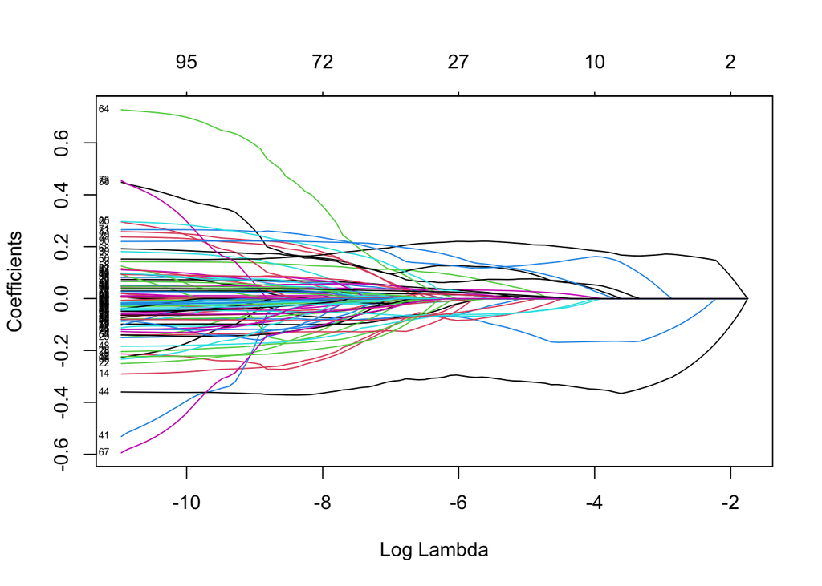

```r
plot(lasso_model, xvar = "lambda", label = TRUE)
```

Next, we need to decide which Lasso model to pick for prediction. Use Cross-Validation for this purpose.

```r
lasso_cv <- cv.glmnet(X, y, alpha = 1)
```

And plot the Cross-validation results.

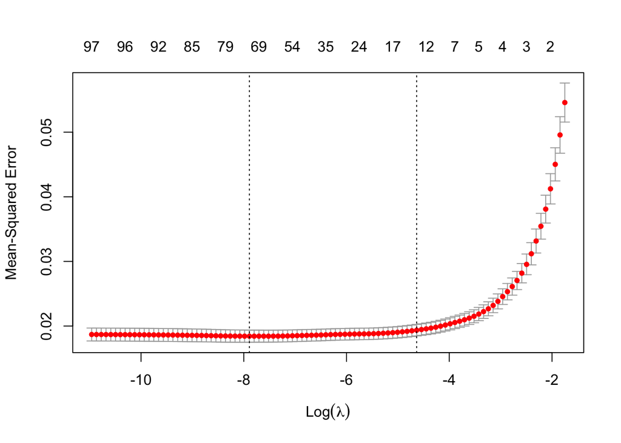

```r
plot(lasso_cv)
```

In your own words, briefly describe the CV plot. (1) What is plotted here, (2) what can you infer about the relation between the number of variables and prediction accuracy?

#### end

Now, store the lambda value of the model with the smallest CV error as `bestlam1`.

```r
coef(lasso_cv, s = "lambda.min")
```

```
## 100 x 1 sparse Matrix of class "dgCMatrix"
##                                 s1
## (Intercept)            0.626454041
## population            -0.073108775
## householdsize          .
## racepctblack           0.124620894
## racePctWhite          -0.079566150
## racePctAsian           .
## racePctHisp            0.014730942
## agePct12t21            .
## agePct12t29           -0.225370484
## agePct16t24            .
## agePct65up             0.058862760
## numbUrban             -0.008814581
## pctUrban               0.040671250
## medIncome              .
## pctWWage              -0.212551924
## pctWFarmSelf           0.023641638
## pctWInvInc            -0.098153924
## pctWSocSec             .
## pctWPubAsst           -0.027943230
## pctWRetire            -0.098877076
## medFamInc              0.028317848
## perCapInc              .
## whitePerCap           -0.106074965
## blackPerCap           -0.001625030
## indianPerCap          -0.022513982
## AsianPerCap            0.011381908
## HispPerCap             0.065523981
## NumUnderPov           -0.041113004
## PctPopUnderPov        -0.161705248
## PctLess9thGrade       -0.077499582
## PctNotHSGrad           0.074030252
## PctBSorMore            0.065865601
## PctUnemployed         -0.005840137
## PctEmploy              0.169552336
## PctEmplManu           -0.051771070
## PctEmplProfServ        .
## PctOccupManu           0.042000521
## PctOccupMgmtProf       0.004341445
```

[output cut: 47 more lines]

```
## MedRent                0.191343088
## MedRentPctHousInc      0.055593706
## MedOwnCostPctInc      -0.049184489
## MedOwnCostPctIncNoMtg -0.084826396
## NumInShelters          0.027152634
## NumStreet              0.217492919
## PctForeignBorn         0.033655726
## PctBornSameState       .
## PctSameHouse85        -0.013489322
## PctSameCity85          0.004563341
## PctSameState85         0.032132804
## LandArea               .
## PopDens               -0.020713292
## PctUsePubTrans        -0.048993232
## LemasPctOfficDrugUn    0.035317249
```

```r
bestlam1 <- lasso_cv$lambda.min
```

Create `bestlalasso_model` as the lambda according to the 1-standard error rule.

```r
lambda_1se <- lasso_cv$lambda.1se
bestlalasso_model <- glmnet(X, y, alpha = 1, lambda = lambda_1se)
```

### Prediction in test set

Finally, we investigate the performance of our models in the test set. For this task, construct a X matrix from the test set.

```r
Xt <- model.matrix(ViolentCrimesPerPop~.-state-communityname-fold,
                  data = crime_test)[,-1]
```

Use the `predict` function to generate predicted values for both models (i.e., both lambdas stored earlier).

```r
# Generate predictions using lambda.min
pred_min <- predict(lasso_cv$glmnet.fit, newx = Xt, s=bestlam1)

# Generate predictions using lambda.1se
pred_1se <- predict(lasso_cv$glmnet.fit, newx = Xt, s=lambda_1se)

# Print first few predicted values for both models
print("Predictions using lambda.min:")
```

```
## [1] "Predictions using lambda.min:"
```

```r
print(head(pred_min))
```

```
##            s1
## 1  0.18232034
## 3  0.35623657
## 6  0.24714751
## 7  0.10683235
## 14 0.03617303
## 16 0.17735969
```

```r
print("Predictions using lambda.1se:")
```

```
## [1] "Predictions using lambda.1se:"
```

```r
print(head(pred_1se))
```

```
##            s1
## 1  0.22558642
## 3  0.34440950
## 6  0.22564394
## 7  0.06931086
## 14 0.02784399
## 16 0.16567335
```

Compute the test MSE of our models.

```r
y_test <- crime_test$ViolentCrimesPerPop
pred_bestlam1 <- predict(lasso_cv$glmnet.fit, newx = Xt, s = bestlam1)
pred_bestlalasso <- predict(lasso_cv$glmnet.fit, newx = Xt, s = lambda_1se)

# Compute MSE for both models
mse_bestlam1 <- mean((y_test - pred_bestlam1)^2)
mse_bestlalasso <- mean((y_test - pred_bestlalasso)^2)

# Print the MSE values
print(paste("Test MSE for bestlam1 (lambda.min):", mse_bestlam1))
```

```
## [1] "Test MSE for bestlam1 (lambda.min): 0.0185969090174034"
```

```r
print(paste("Test MSE for bestlalasso_model (lambda.1se):", mse_bestlalasso))
```

```
## [1] "Test MSE for bestlalasso_model (lambda.1se): 0.0192519302735911"
```

In addition, use another performance metric and compute the corresponding values for both models.

```r
# Compute Mean Absolute Error (MAE) for both models
mae_bestlam1 <- mean(abs(y_test - pred_bestlam1))
mae_bestlalasso <- mean(abs(y_test - pred_bestlalasso))

# Print the MAE values
print(paste("Test MAE for bestlam1 (lambda.min):", mae_bestlam1))
```

```
## [1] "Test MAE for bestlam1 (lambda.min): 0.0949489822614771"
```

```r
print(paste("Test MAE for bestlalasso_model (lambda.1se):", mae_bestlalasso))
```

```
## [1] "Test MAE for bestlalasso_model (lambda.1se): 0.0959548891609138"
```

Which model is better? Does it depend on the performance measure that is used?

### Does it depend on the performance measure?

In this case, both **MSE and MAE agree** that the **bestlam1 model is better**. However, different performance measures can sometimes favor different models.

- **MSE** penalizes large errors more due to squaring the differences, making it more sensitive to outliers.
- **MAE** is more robust to outliers but does not differentiate between small and large errors as strongly as MSE.